# Group Project

Varun Selvam, Ahsan Ahmad, Richard Lim

2023-11-26

## Introduction & Project goal

### Introduction

In this group project, we are expecting to build the maximum predictive accuracy by using all available predictors & interactions. There are no restriction on variables to utilize, or on combinations of variables—interactions and polynomial terms may be utilized if appropriate.

### Project goal

This group project is aimed to develop a linear model predicting housing prices in Ames, IA using the data sets provided from **Kaggle.com**. Model performance benchmark for minimum estimated out-of-sample $R^2$ is 0.85, along with a Kaggle Score less than 0.15.

## Description of the data

### Description

There are two datasets for the group project. One is `train.csv` and the other is `test.csv` which are with 1460 and 1459 observations, respectively. Data includes the categorical & numeric features of properties (Predictors) and their corresponding `SalePrice`. (Target)

### Data Profile

- SalePrice - the property’s sale price in dollars. This is the target variable that you’re trying to predict.
- MSSubClass: The building class
- MSZoning: The general zoning classification
- LotFrontage: Linear feet of street connected to property
- LotArea: Lot size in square feet
- Street: Type of road access
- Alley: Type of alley access
- LotShape: General shape of property
- LandContour: Flatness of the property
- Utilities: Type of utilities available
- LotConfig: Lot configuration
- LandSlope: Slope of property
- Neighborhood: Physical locations within Ames city limits
- Condition1: Proximity to main road or railroad
- Condition2: Proximity to main road or railroad (if a second is present)
- BldgType: Type of dwelling
- HouseStyle: Style of dwelling
- OverallQual: Overall material and finish quality
- OverallCond: Overall condition rating
- YearBuilt: Original construction date
- YearRemodAdd: Remodel date
- RoofStyle: Type of roof
- RoofMatl: Roof material
- Exterior1st: Exterior covering on house
- Exterior2nd: Exterior covering on house (if more than one material)
- MasVnrType: Masonry veneer type
- MasVnrArea: Masonry veneer area in square feet
- ExterQual: Exterior material quality
- ExterCond: Present condition of the material on the exterior
- Foundation: Type of foundation
- BsmtQual: Height of the basement
- BsmtCond: General condition of the basement
- BsmtExposure: Walkout or garden level basement walls
- BsmtFinType1: Quality of basement finished area
- BsmtFinSF1: Type 1 finished square feet
- BsmtFinType2: Quality of second finished area (if present)
- BsmtFinSF2: Type 2 finished square feet
- BsmtUnfSF: Unfinished square feet of basement area
- TotalBsmtSF: Total square feet of basement area
- Heating: Type of heating
- HeatingQC: Heating quality and condition
- CentralAir: Central air conditioning
- Electrical: Electrical system
- 1stFlrSF: First Floor square feet
- 2ndFlrSF: Second floor square feet
- LowQualFinSF: Low quality finished square feet (all floors)
- GrLivArea: Above grade (ground) living area square feet
- BsmtFullBath: Basement full bathrooms
- BsmtHalfBath: Basement half bathrooms
- FullBath: Full bathrooms above grade
- HalfBath: Half baths above grade
- Bedroom: Number of bedrooms above basement level
- Kitchen: Number of kitchens
- KitchenQual: Kitchen quality
- TotRmsAbvGrd: Total rooms above grade (does not include bathrooms)
- Functional: Home functionality rating
- Fireplaces: Number of fireplaces
- FireplaceQu: Fireplace quality
- GarageType: Garage location
- GarageYrBlt: Year garage was built
- GarageFinish: Interior finish of the garage
- GarageCars: Size of garage in car capacity
- GarageArea: Size of garage in square feet
- GarageQual: Garage quality
- GarageCond: Garage condition
- PavedDrive: Paved driveway
- WoodDeckSF: Wood deck area in square feet
- OpenPorchSF: Open porch area in square feet
- EnclosedPorch: Enclosed porch area in square feet
- 3SsnPorch: Three season porch area in square feet
- ScreenPorch: Screen porch area in square feet
- PoolArea: Pool area in square feet
- PoolQC: Pool quality
- Fence: Fence quality
- MiscFeature: Miscellaneous feature not covered in other categories
- MiscVal: $Value of miscellaneous feature
- MoSold: Month Sold
- YrSold: Year Sold
- SaleType: Type of sale
- SaleCondition: Condition of sale

## Load Libraries

```r
# load libraries for project
library(dplyr)
library(ggplot2)
library(tidyr)
library(rpart)
library(rpart.plot)
```

## Load dataset

```r
# load Data sets
train <- read.csv("train.csv")
test <- read.csv("test.csv")
```

```r
# 5 sameples of train.csv
head(train)
```

|  | Id | MSSubClass | MSZoning | LotFrontage | LotArea | Street | Alley | LotShape | LandContour | Utilities | LotConfig | LandSlope | Neighborhood | Condition1 | Condition2 | BldgType | HouseStyle | OverallQual | OverallCond | YearBuilt | YearRemodAdd | RoofStyle | RoofMatl | Exterior1st | Exterior2nd | MasVnrType | MasVnrArea | ExterQual | ExterCond | … |
| --- | --- | --- | --- | --- | --- | --- | --- | --- | --- | --- | --- | --- | --- | --- | --- | --- | --- | --- | --- | --- | --- | --- | --- | --- | --- | --- | --- | --- | --- | --- |
| 1 | 1 | 60 | RL | 65 | 8450 | Pave | NA | Reg | Lvl | AllPub | Inside | Gtl | CollgCr | Norm | Norm | 1Fam | 2Story | 7 | 5 | 2003 | 2003 | Gable | CompShg | VinylSd | VinylSd | BrkFace | 196 | Gd | TA | … |
| 2 | 2 | 20 | RL | 80 | 9600 | Pave | NA | Reg | Lvl | AllPub | FR2 | Gtl | Veenker | Feedr | Norm | 1Fam | 1Story | 6 | 8 | 1976 | 1976 | Gable | CompShg | MetalSd | MetalSd | None | 0 | TA | TA | … |
| 3 | 3 | 60 | RL | 68 | 11250 | Pave | NA | IR1 | Lvl | AllPub | Inside | Gtl | CollgCr | Norm | Norm | 1Fam | 2Story | 7 | 5 | 2001 | 2002 | Gable | CompShg | VinylSd | VinylSd | BrkFace | 162 | Gd | TA | … |
| 4 | 4 | 70 | RL | 60 | 9550 | Pave | NA | IR1 | Lvl | AllPub | Corner | Gtl | Crawfor | Norm | Norm | 1Fam | 2Story | 7 | 5 | 1915 | 1970 | Gable | CompShg | Wd Sdng | Wd Shng | None | 0 | TA | TA | … |
| 5 | 5 | 60 | RL | 84 | 14260 | Pave | NA | IR1 | Lvl | AllPub | FR2 | Gtl | NoRidge | Norm | Norm | 1Fam | 2Story | 8 | 5 | 2000 | 2000 | Gable | CompShg | VinylSd | VinylSd | BrkFace | 350 | Gd | TA | … |
| 6 | 6 | 50 | RL | 85 | 14115 | Pave | NA | IR1 | Lvl | AllPub | Inside | Gtl | Mitchel | Norm | Norm | 1Fam | 1.5Fin | 5 | 5 | 1993 | 1995 | Gable | CompShg | VinylSd | VinylSd | None | 0 | TA | TA | … |

```r
dim(train) #Dim to see how many variables are in the train dataset.
```

```
## [1] 1460   81
```

```r
# 5 sameples of test.csv
head(test) #See first 6 values of the train set.
```

|  | Id | MSSubClass | MSZoning | LotFrontage | LotArea | Street | Alley | LotShape | LandContour | Utilities | LotConfig | LandSlope | Neighborhood | Condition1 | Condition2 | BldgType | HouseStyle | OverallQual | OverallCond | YearBuilt | YearRemodAdd | RoofStyle | RoofMatl | Exterior1st | Exterior2nd | MasVnrType | MasVnrArea | ExterQual | ExterCond | … |
| --- | --- | --- | --- | --- | --- | --- | --- | --- | --- | --- | --- | --- | --- | --- | --- | --- | --- | --- | --- | --- | --- | --- | --- | --- | --- | --- | --- | --- | --- | --- |
| 1 | 1461 | 20 | RH | 80 | 11622 | Pave | NA | Reg | Lvl | AllPub | Inside | Gtl | NAmes | Feedr | Norm | 1Fam | 1Story | 5 | 6 | 1961 | 1961 | Gable | CompShg | VinylSd | VinylSd | None | 0 | TA | TA | … |
| 2 | 1462 | 20 | RL | 81 | 14267 | Pave | NA | IR1 | Lvl | AllPub | Corner | Gtl | NAmes | Norm | Norm | 1Fam | 1Story | 6 | 6 | 1958 | 1958 | Hip | CompShg | Wd Sdng | Wd Sdng | BrkFace | 108 | TA | TA | … |
| 3 | 1463 | 60 | RL | 74 | 13830 | Pave | NA | IR1 | Lvl | AllPub | Inside | Gtl | Gilbert | Norm | Norm | 1Fam | 2Story | 5 | 5 | 1997 | 1998 | Gable | CompShg | VinylSd | VinylSd | None | 0 | TA | TA | … |
| 4 | 1464 | 60 | RL | 78 | 9978 | Pave | NA | IR1 | Lvl | AllPub | Inside | Gtl | Gilbert | Norm | Norm | 1Fam | 2Story | 6 | 6 | 1998 | 1998 | Gable | CompShg | VinylSd | VinylSd | BrkFace | 20 | TA | TA | … |
| 5 | 1465 | 120 | RL | 43 | 5005 | Pave | NA | IR1 | HLS | AllPub | Inside | Gtl | StoneBr | Norm | Norm | TwnhsE | 1Story | 8 | 5 | 1992 | 1992 | Gable | CompShg | HdBoard | HdBoard | None | 0 | Gd | TA | … |
| 6 | 1466 | 60 | RL | 75 | 10000 | Pave | NA | IR1 | Lvl | AllPub | Corner | Gtl | Gilbert | Norm | Norm | 1Fam | 2Story | 6 | 5 | 1993 | 1994 | Gable | CompShg | HdBoard | HdBoard | None | 0 | TA | TA | … |

```r
dim(test) # Dim to show many variables there are in this dataset.
```

```
## [1] 1459   80
```

Display the first 6 values of the Train Set, to gain a perspective of the data and its variables. There are additionally 81 total variables in the train dataset.

## Data Summarization

### Numeric data summary

```r
mean <- train %>% # Pipe changes from train dataset and assign to a new variable.
  select_if(is.numeric) %>% # Select value if numeric
  summarise_all(~mean(.x, na.rm = TRUE)) %>% # Summarise mean for all numeric columns.
  pivot_longer(cols = everything(), names_to = "columns", values_to = "mean") # Create two new columns with the column name and the mean.

min <- train %>% # Pipe changes from train dataset and assign to a new variable.
  select_if(is.numeric) %>% # Select value if numeric
  summarise_all(~min(.x, na.rm = TRUE)) %>% # Summarise min value for all numeric columns.
  pivot_longer(cols = everything(), names_to = "columns", values_to = "min") # Create two new columns with the column name and the min.

max <- train %>% # Pipe changes from train dataset and assign to a new variable.
  select_if(is.numeric) %>% # Select value if numeric
  summarise_all(~max(.x, na.rm = TRUE)) %>% # Summarise max value for all numeric columns
  pivot_longer(cols = everything(), names_to = "columns", values_to = "max") # Create two new columns with the column name and the max.

variance <- train %>% # Pipe changes from train dataset and assign to a new variable.
  select_if(is.numeric) %>% # Select value if numeric
  summarise_all(~var(.x, na.rm = TRUE)) %>% # Summarise variance for all numeric columns
  pivot_longer(cols = everything(), names_to = "columns", values_to = "variance") # Create two new columns with the column name and the variance.

sd <- train %>% # Pipe changes from train dataset and assign to a new variable.
  select_if(is.numeric) %>% # Select value if numeric
  summarise_all(~sd(.x, na.rm = TRUE)) %>% # Summarise standard deviation for all numeric columns
  pivot_longer(cols = everything(), names_to = "columns", values_to = "standard deviation")  #Create two new columns with the column name and the standard deviation



mean %>%
  left_join(min, by = "columns") %>%
  left_join(max, by = "columns") %>%
  left_join(variance, by = "columns") %>%
  left_join(sd, by = "columns")
```

| columns | mean | min | max | variance | standard deviation |
| --- | --- | --- | --- | --- | --- |
| Id | 7.305000e+02 | 1 | 1460 | 1.777550e+05 | 421.6100094 |
| MSSubClass | 5.689726e+01 | 20 | 190 | 1.789338e+03 | 42.3005710 |
| LotFrontage | 7.004996e+01 | 21 | 313 | 5.897492e+02 | 24.2847518 |
| LotArea | 1.051683e+04 | 1300 | 215245 | 9.962565e+07 | 9981.2649324 |
| OverallQual | 6.099315e+00 | 1 | 10 | 1.912679e+00 | 1.3829965 |
| OverallCond | 5.575342e+00 | 1 | 9 | 1.238322e+00 | 1.1127993 |
| YearBuilt | 1.971268e+03 | 1872 | 2010 | 9.122154e+02 | 30.2029040 |
| YearRemodAdd | 1.984866e+03 | 1950 | 2010 | 4.262328e+02 | 20.6454068 |
| MasVnrArea | 1.036853e+02 | 0 | 1600 | 3.278497e+04 | 181.0662066 |
| BsmtFinSF1 | 4.436397e+02 | 0 | 5644 | 2.080255e+05 | 456.0980908 |

[output cut: 28 more lines]

### Categorical Data Summary

```r
lapply(train %>% #Pipe changes to the train data set
         select_if(is.character), unique) #Select the unique values for each categorical variable.
```

```
## $MSZoning
## [1] "RL"      "RM"      "C (all)" "FV"      "RH"
##
## $Street
## [1] "Pave" "Grvl"
##
## $Alley
## [1] NA     "Grvl" "Pave"
##
## $LotShape
## [1] "Reg" "IR1" "IR2" "IR3"
##
## $LandContour
## [1] "Lvl" "Bnk" "Low" "HLS"
##
## $Utilities
## [1] "AllPub" "NoSeWa"
##
## $LotConfig
## [1] "Inside"  "FR2"     "Corner"  "CulDSac" "FR3"
##
## $LandSlope
## [1] "Gtl" "Mod" "Sev"
##
## $Neighborhood
##  [1] "CollgCr" "Veenker" "Crawfor" "NoRidge" "Mitchel" "Somerst" "NWAmes"
##  [8] "OldTown" "BrkSide" "Sawyer"  "NridgHt" "NAmes"   "SawyerW" "IDOTRR"
## [15] "MeadowV" "Edwards" "Timber"  "Gilbert" "StoneBr" "ClearCr" "NPkVill"
## [22] "Blmngtn" "BrDale"  "SWISU"   "Blueste"
##
## $Condition1
## [1] "Norm"   "Feedr"  "PosN"   "Artery" "RRAe"   "RRNn"   "RRAn"   "PosA"
## [9] "RRNe"
##
## $Condition2
## [1] "Norm"   "Artery" "RRNn"   "Feedr"  "PosN"   "PosA"   "RRAn"   "RRAe"
##
## $BldgType
## [1] "1Fam"   "2fmCon" "Duplex" "TwnhsE" "Twnhs"
##
```

[output cut: 82 more lines]

```
##
## $PoolQC
## [1] NA   "Ex" "Fa" "Gd"
##
## $Fence
## [1] NA      "MnPrv" "GdWo"  "GdPrv" "MnWw"
##
## $MiscFeature
## [1] NA     "Shed" "Gar2" "Othr" "TenC"
##
## $SaleType
## [1] "WD"    "New"   "COD"   "ConLD" "ConLI" "CWD"   "ConLw" "Con"   "Oth"
##
## $SaleCondition
## [1] "Normal"  "Abnorml" "Partial" "AdjLand" "Alloca"  "Family"
```

Displays a list for easy reference, that shows the unique values for each categorical variable.

## Data Missing Handling

```r
count_missings <- function(x) sum(is.na(x)) # Sum provides a total of how many values are missing for each variable.

# Summarizes all the missing values for each variable.
train %>% # Data set name
  summarize_all(count_missings) %>%
  t()
```

```
##               [,1]
## Id               0
## MSSubClass       0
## MSZoning         0
## LotFrontage    259
## LotArea          0
## Street           0
## Alley         1369
## LotShape         0
## LandContour      0
## Utilities        0
## LotConfig        0
## LandSlope        0
## Neighborhood     0
## Condition1       0
## Condition2       0
## BldgType         0
## HouseStyle       0
## OverallQual      0
## OverallCond      0
## YearBuilt        0
## YearRemodAdd     0
## RoofStyle        0
## RoofMatl         0
## Exterior1st      0
## Exterior2nd      0
## MasVnrType       8
## MasVnrArea       8
## ExterQual        0
## ExterCond        0
## Foundation       0
## BsmtQual        37
## BsmtCond        37
## BsmtExposure    38
## BsmtFinType1    37
## BsmtFinSF1       0
## BsmtFinType2    38
## BsmtFinSF2       0
## BsmtUnfSF        0
## TotalBsmtSF      0
```

[output cut: 27 more lines]

```
## WoodDeckSF       0
## OpenPorchSF      0
## EnclosedPorch    0
## X3SsnPorch       0
## ScreenPorch      0
## PoolArea         0
## PoolQC        1453
## Fence         1179
## MiscFeature   1406
## MiscVal          0
## MoSold           0
## YrSold           0
## SaleType         0
## SaleCondition    0
## SalePrice        0
```

We will continue further with our analysis and check that any of the selected predictors for the model are not missing values. Finally this table also helps give perspective on which variables may be missing several values like Alley (1369 missing values), Pool QC(1453 missing values) and Fence (1179 missing values).

## Variable Selection

```r
# Methodology 1: Classification Tree (rpart function)
train_tree <- train %>% #Assign changes to train data set to a new variable
  select(-Id) #Remove ID as a predictor, it's not needed.

house_prices_tree <- rpart(formula = SalePrice ~ ., data = train_tree)
# Assign tree to a variable titled "house_prices_tree".
house_prices_tree #Display Tree
```

```
## n= 1460
##
## node), split, n, deviance, yval
##       * denotes terminal node
##
##  1) root 1460 9207911000000 180921.2
##    2) OverallQual< 7.5 1231 2987549000000 157832.4
##      4) Neighborhood=Blueste,BrDale,BrkSide,Edwards,IDOTRR,MeadowV,Mitchel,NAmes,NPkVill,OldTown,Sawyer,SWISU 713  874553500000 132242.5
##        8) X1stFlrSF< 1050.5 410  325435600000 118198.6 *
##        9) X1stFlrSF>=1050.5 303  358833900000 151245.7 *
##      5) Neighborhood=Blmngtn,ClearCr,CollgCr,Crawfor,Gilbert,NoRidge,NridgHt,NWAmes,SawyerW,Somerst,StoneBr,Timber,Veenker 518 1003420000000 193055.7
##       10) GrLivArea< 1719 350  377069800000 176242.8
##         20) GrLivArea< 1120 63   23302790000 135391.3 *
##         21) GrLivArea>=1120 287  225550400000 185210.3 *
##       11) GrLivArea>=1719 168  321301500000 228082.4
##         22) BsmtFinSF1< 860.5 138  168333200000 217077.2 *
##         23) BsmtFinSF1>=860.5 30   59371410000 278706.2 *
##    3) OverallQual>=7.5 229 2036506000000 305035.9
##      6) OverallQual< 8.5 168  681872600000 274735.5
##       12) GrLivArea< 1971.5 103  240207200000 249392.5 *
##       13) GrLivArea>=1971.5 65  270683000000 314894.6 *
##      7) OverallQual>=8.5 61  775590500000 388486.1
##       14) GrLivArea< 2229 35   77633010000 341248.2 *
##       15) GrLivArea>=2229 26  514723800000 452075.5 *
```

Based on this classification tree, the top predictors are:

- Overall Quality
- Neighborhood
- First Floor Sqft
- Ground Living Area
- Basement Finished Sqft 1

```r
# Methodology 2: Removing all predictors with even one NA value and saving it to a dataset.

without_na_train <-
  train %>%
  select(names(which(colSums(is.na(.)) == 0)))


# Creating a Multiple Linear Regression Model with all the remaining predictors
model_a <- lm(SalePrice ~ ., data = without_na_train)
model_a_summary <- summary(model_a)



# Creating a Dataframe with Predictor/Variable name and it's corresponding P-Value and arranging it in ascending order to get the top 5 predictors
p_values <- model_a_summary$coefficients[, "Pr(>|t|)"]
coefficients_p_value <- data.frame(
  Variable_name = rownames(model_a_summary$coefficients),
  P_Value = p_values
)


coefficients_p_value %>%
  arrange(P_Value) %>%
  head(n = 70)
```

|  | Variable_name | P_Value |
| --- | --- | --- |
| RoofMatlWdShngl | RoofMatlWdShngl | 3.507660e-86 |
| RoofMatlCompShg | RoofMatlCompShg | 8.958658e-76 |
| RoofMatlTar&Grv | RoofMatlTar&Grv | 2.284001e-60 |
| RoofMatlWdShake | RoofMatlWdShake | 1.231063e-59 |
| RoofMatlRoll | RoofMatlRoll | 1.027869e-50 |
| RoofMatlMembran | RoofMatlMembran | 1.668892e-49 |
| RoofMatlMetal | RoofMatlMetal | 8.195861e-46 |
| X2ndFlrSF | X2ndFlrSF | 2.837790e-38 |
| X1stFlrSF | X1stFlrSF | 3.125304e-24 |
| BsmtFinSF1 | BsmtFinSF1 | 1.032993e-16 |

[output cut: 60 more lines]

We have determined the predictors based on the p-value of linear model and through multiple iterative combinations with other predictors to gauge which predictors produce the best fit. (Some of the predictors in this table have already been identified from the Classification Tree like Overall Quality and First Floor Sqft, so they won’t be listed here again, since this list is for the predictors we got based of the p-value.)

- RoofMatl (Roof Material)
- X2ndFlrSF (Second Floor Sqft)
- KitchenQual (Kitchen Quality)
- OverallCond (Overall Condition)
- ExterQual (External Quality)
- Year Built
- BsmtFinSF2 (Basement Finished Sqft 2)
- Condition1
- Sale Type
- Utilities
- Lot Area

Based on the two methodologies (Rpart tree & non-NA linear model) combined, we are selecting the following predictors as:

-OverallQual -Neighborhood -X1stFlrSF -GrLivArea -BsmtFinSF1 -RoofMatl -SaleType -Utilities -Condition1 -YearBuilt -X2ndFlrSF -KitchenQual -LotArea -ExterQual -OverallCond -BsmtFinSF2

```r
#Summarize any missing variables in the train dataset
train %>% #Dat Set name
  select(OverallQual, Neighborhood, X1stFlrSF, GrLivArea, BsmtFinSF1, RoofMatl, SaleType, Utilities, Condition1, YearBuilt, X2ndFlrSF, KitchenQual, LotArea, ExterQual, OverallCond, BsmtFinSF2 ) %>% # Predictors that this model will utilize.
  summarize_all(count_missings) # Show all missing values for the selected variables.
```

| OverallQual | Neighborhood | X1stFlrSF | GrLivArea | BsmtFinSF1 | RoofMatl | SaleType | Utilities | Condition1 | YearBuilt | X2ndFlrSF | KitchenQual | LotArea | ExterQual | OverallCond | BsmtFinSF2 |
| --- | --- | --- | --- | --- | --- | --- | --- | --- | --- | --- | --- | --- | --- | --- | --- |
| 0 | 0 | 0 | 0 | 0 | 0 | 0 | 0 | 0 | 0 | 0 | 0 | 0 | 0 | 0 | 0 |

The table above shows if there are any missing values for the specific predictors that we have chosen. Based of that table, there are no missing values for the selected predictors.

## Data Cleansing

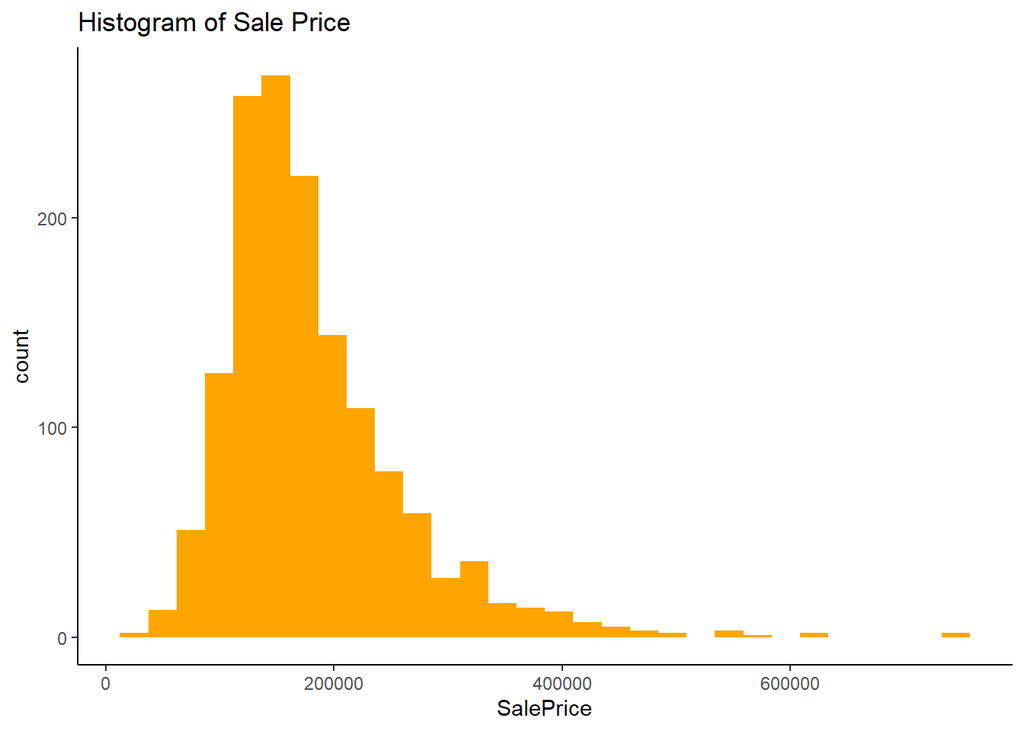

```r
ggplot(data = train, mapping = aes(x = SalePrice)) + # x-axis is Sales Price
  geom_histogram(fill = 'orange') + # Plot type which is histogram
  labs(title = "Histogram of Sale Price") + # Title for histogram
  theme_classic() # Classic theme to minimize background elements.
```

The Histogram for Sale Price is right skewed, however much of the data still appears to be near the center. This means that a log transformation although, helpful will not be necessary.

## Change variables as factor

```r
# overwrite original dataset with the new changes
train <- train %>%
  mutate(OverallQual = factor(OverallQual)) %>% # Change Overall Quality into a factor.
  mutate(Neighborhood = factor(Neighborhood)) %>% # Change Neighborhood into a factor.
  mutate(RoofMatl = factor(RoofMatl)) %>% # Change Roof Material into a factor.
  mutate(SaleType = factor(SaleType)) %>% # Change Sale Type into a factor.
  mutate(Utilities = factor(Utilities)) %>% # Change Utilities into a factor.
  mutate(Condition1 = factor(Condition1)) %>% # Change Condition 1 into a factor.
  mutate(KitchenQual = factor(KitchenQual)) %>% # Change Kitchen the into a factor.
  mutate(ExterQual = factor(ExterQual)) %>% # Change External Quality into a factor.
  mutate(OverallCond = factor(OverallCond)) # Change Overall Condition into a factor.

#R should convert any character variables into factors automatically, however just want to be precautious.
```

These variables have been chosen to be converted into factors because they have multiple levels to their responses and the response level means something distinct. For instance, Roof Material represents different types of materials which is why it was converted into a factor.

## Data split for validation

```r
#Set seed for reproducibility
set.seed(100)
index <- sample(x = 1:nrow(train), size = nrow(train)*.7, replace = F) # Randomly sample 70% of the rows

head(index) # Display row numbers.
```

```
## [1]  503 1382  985 1004  919  470
```

```r
# Subset train using the index and assign it to train_fold.
train_fold <- train[index, ]

# Subset all remaining rows into the validation fold.
validation_fold <- train[-index, ]
```

These numbers have been verified to be the same after multiple reruns. This is due to the seed which makes it possible to reproduce this data-set.

## Interaction model

### Interaction 1

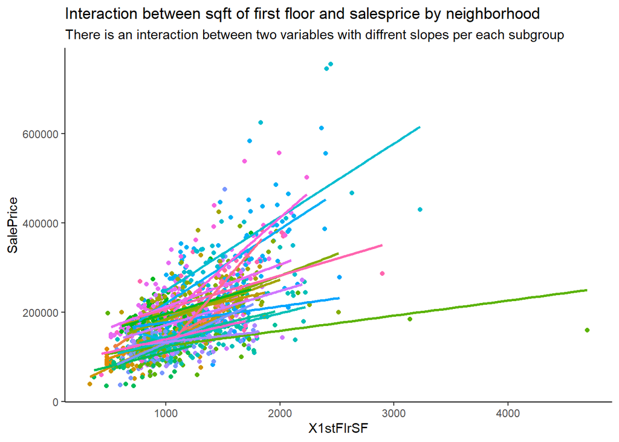

```r
train %>% #Pipe changes to train dataset
  ggplot(aes(x = X1stFlrSF, y = SalePrice, color = Neighborhood)) + #x-axis: 1st Floor Sqft, #y-axis: SalePrice
  geom_point(show.legend = FALSE) + # Hide legend
  geom_smooth(method = lm, se = FALSE, show.legend = FALSE) + # Linear Regression Model to show interaction relationship between 2nd Floor Saft and Sale Price with Neighborhood.
  labs(title = "Interaction between sqft of first floor and salesprice by neighborhood",
       subtitle= "There is an interaction between two variables with diffrent slopes per each subgroup") + #Title for lab
  theme_classic() # Theme Classic to help make interaction model more prominent by minimzing background elements.
```

Per the subtitle plot, this plot shows that neighborhood does have an effect on the relationship between 1st Floor Sqft and Sale Price.

### Interaction 2

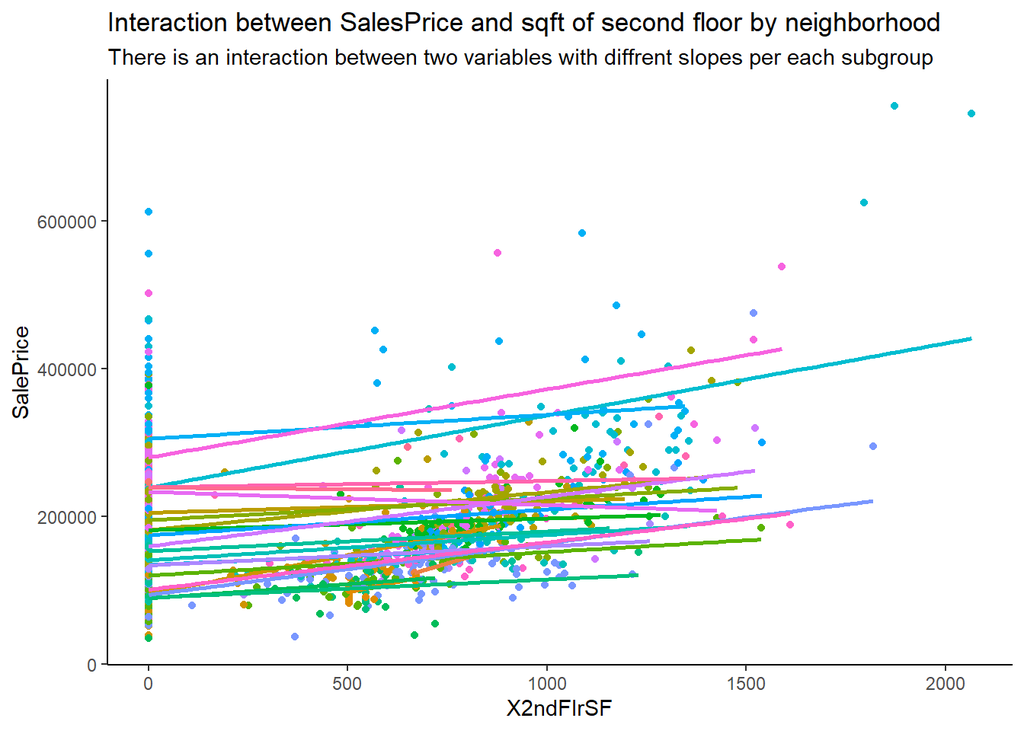

```r
train %>% #pipe changes to train dataset
  ggplot(aes(x = X2ndFlrSF, y = SalePrice, color = Neighborhood)) + #x-axis: 2nd Floor Sqft, #y-axis: SalePrice
  geom_point(show.legend = FALSE) + # Hide legend
  geom_smooth(method = lm, se = FALSE, show.legend = FALSE) + # Linear Regression Model to show interaction relationship between 2nd Floor Saft and Sale Price with Neighborhood.
  labs(title = "Interaction between SalesPrice and sqft of second floor by neighborhood",
       subtitle= "There is an interaction between two variables with diffrent slopes per each subgroup") + #Title for lab
  theme_classic() #Theme Classic to help make interaction model more prominent by minimzing background elements.
```

Per the subtitle plot, this plot shows that neighborhood does have an effect on the relationship between 2nd Floor Sqft and Sale Price.

## Data Modeling

```r
SalePrice_Model <- lm(SalePrice ~ OverallQual + YearBuilt + Neighborhood * X1stFlrSF + GrLivArea + BsmtFinSF1 + RoofMatl + Neighborhood * X2ndFlrSF + SaleType + Utilities + Condition1 + KitchenQual + LotArea + ExterQual + OverallCond + BsmtFinSF2, data = train_fold) #Data must be train-fold because we are training the model, so train_fold data should be used.

summary(SalePrice_Model) #Provide summary of the Sale Price Model.
```

```
##
## Call:
## lm(formula = SalePrice ~ OverallQual + YearBuilt + Neighborhood *
##     X1stFlrSF + GrLivArea + BsmtFinSF1 + RoofMatl + Neighborhood *
##     X2ndFlrSF + SaleType + Utilities + Condition1 + KitchenQual +
##     LotArea + ExterQual + OverallCond + BsmtFinSF2, data = train_fold)
##
## Residuals:
##     Min      1Q  Median      3Q     Max
## -140541   -9510       0   10070  138439
##
## Coefficients: (3 not defined because of singularities)
##                                 Estimate Std. Error t value Pr(>|t|)
## (Intercept)                   -1.424e+06  1.648e+05  -8.638  < 2e-16 ***
## OverallQual2                  -2.906e+04  4.232e+04  -0.687 0.492501
## OverallQual3                  -2.623e+04  2.827e+04  -0.928 0.353669
## OverallQual4                  -2.313e+04  2.778e+04  -0.833 0.405266
## OverallQual5                  -2.252e+04  2.796e+04  -0.806 0.420706
## OverallQual6                  -1.247e+04  2.800e+04  -0.445 0.656117
## OverallQual7                   1.988e+03  2.805e+04   0.071 0.943508
## OverallQual8                   2.842e+04  2.825e+04   1.006 0.314623
## OverallQual9                   5.982e+04  2.876e+04   2.080 0.037834 *
## OverallQual10                  1.018e+05  2.993e+04   3.400 0.000703 ***
## YearBuilt                      4.050e+02  6.831e+01   5.929 4.36e-09 ***
## NeighborhoodBlueste           -1.276e+04  6.187e+04  -0.206 0.836694
## NeighborhoodBrDale             9.865e+03  1.123e+05   0.088 0.930047
## NeighborhoodBrkSide            6.645e+04  9.181e+04   0.724 0.469376
## NeighborhoodClearCr            1.300e+05  9.561e+04   1.359 0.174354
## NeighborhoodCollgCr            6.334e+04  8.999e+04   0.704 0.481661
## NeighborhoodCrawfor            9.862e+04  9.046e+04   1.090 0.275934
## NeighborhoodEdwards            8.435e+04  9.031e+04   0.934 0.350547
## NeighborhoodGilbert            5.738e+04  9.153e+04   0.627 0.530898
## NeighborhoodIDOTRR             5.027e+04  9.268e+04   0.542 0.587703
## NeighborhoodMeadowV            8.115e+04  9.170e+04   0.885 0.376462
## NeighborhoodMitchel            8.926e+04  9.072e+04   0.984 0.325436
## NeighborhoodNAmes              1.008e+05  8.980e+04   1.122 0.261975
## NeighborhoodNoRidge           -4.640e+04  9.203e+04  -0.504 0.614202
## NeighborhoodNPkVill            1.758e+05  6.066e+05   0.290 0.771978
## NeighborhoodNridgHt           -5.037e+04  9.142e+04  -0.551 0.581796
## NeighborhoodNWAmes             1.111e+05  9.094e+04   1.222 0.221970
```

[output cut: 91 more lines]

```
## NeighborhoodNWAmes:X2ndFlrSF  -6.365e+01  4.204e+01  -1.514 0.130413
## NeighborhoodOldTown:X2ndFlrSF -6.266e+01  4.190e+01  -1.495 0.135156
## NeighborhoodSawyer:X2ndFlrSF  -6.459e+01  4.234e+01  -1.526 0.127467
## NeighborhoodSawyerW:X2ndFlrSF -3.926e+01  4.163e+01  -0.943 0.345856
## NeighborhoodSomerst:X2ndFlrSF -1.558e+01  4.266e+01  -0.365 0.715062
## NeighborhoodStoneBr:X2ndFlrSF  7.137e-01  4.215e+01   0.017 0.986494
## NeighborhoodSWISU:X2ndFlrSF   -3.611e+01  4.763e+01  -0.758 0.448653
## NeighborhoodTimber:X2ndFlrSF  -4.320e+01  4.261e+01  -1.014 0.310967
## NeighborhoodVeenker:X2ndFlrSF         NA         NA      NA       NA
## ---
## Signif. codes:  0 '***' 0.001 '**' 0.01 '*' 0.05 '.' 0.1 ' ' 1
##
## Residual standard error: 22240 on 897 degrees of freedom
## Multiple R-squared:  0.9297, Adjusted R-squared:   0.92
## F-statistic: 96.42 on 123 and 897 DF,  p-value: < 2.2e-16
```

```r
rmse <- function(observed, predicted) sqrt(mean((observed - predicted)^2)) #Create RMSE function for test data

R2 <- function(observed, predicted){ #Create R-Squared function for test data
  TSS <- sum((observed - mean(observed))^2)
  RSS <- sum((observed - predicted)^2)
  1- RSS/TSS
}

# Calculate Estimated RMSE
rmse(observed = train_fold$SalePrice, #observed is the SalePrice values that are already in the dataset.
     predicted = fitted(SalePrice_Model)) #fitted represents the values that the model predicted.
```

```
## [1] 20845.86
```

```r
R2(train_fold$SalePrice, fitted(SalePrice_Model))
```

```
## [1] 0.9296826
```

The “In Sample” R-squared is .92 which means that this model explains 92% of the variation for the In Sample Data set. In the context of this model, 92% of the model’s predictions for Sale Price fit very closely with the actual values for Sale Price.

The estimated RMSE indicates that this model’s predictions are off on average by $20845.86 when estimating the Sale Price of a house.

## Data model performance for validation

```r
predictions <- predict(SalePrice_Model, newdata = validation_fold) #Use SalePrice_Model for predictions and the validation fold for the cross validation dataset.

# Utilize previously created functions for calculating RMSE and R-squared (necessary for estimating Out of sample performance)

rmse(validation_fold$SalePrice, predictions)
```

```
## [1] 29074.05
```

```r
R2(validation_fold$SalePrice, predictions)
```

```
## [1] 0.8719141
```

This model has an out of sample R-Squared of 87% which means that this model explains 87% of the variation in the data. In the context of this model, 87% of the model’s predictions for Sale Price fit very closely with the actual values for Sale Price. The “In Sample” model had an R-Squared of 92% while the validation model had an R-Square of 87%.

Most models will face a similar decline in R-Squared when they are ran with the validation fold data. However if a model experiences a massive decline in R-Squared, this is indicative of over-fitting. In this case, since there was a modest decline, this indicates that the Sale Price Model is not overfitting.

The RMSE indicates that this model’s predictions are off on average by $29,074.05 dollars when estimating the Sale Price of a house.

## Data Engineering for test dataset

```r
test <- test %>%  #Override test dataset with changes to make test dataset match the train dataset.
  mutate(OverallQual = factor(OverallQual)) %>% # Change Overall Quality to a factor.
  mutate(Neighborhood = factor(Neighborhood)) %>% # Change Neighborhood into a factor.
  mutate(RoofMatl = factor(RoofMatl)) %>% # Change Roof Material into a factor.
  mutate(SaleType = factor(SaleType)) %>% # Change Sale Type into a factor.
  mutate(Utilities = factor(Utilities)) %>% # Change Utilities into a factor.
  mutate(Condition1 = factor(Condition1)) %>% # Change Condition1 into a factor.
  mutate(KitchenQual = factor(KitchenQual)) %>% # Change Kitchen Quality into a factor.
  mutate(ExterQual = factor(ExterQual)) %>% # Change External Quality into a factor.
  mutate(OverallCond = factor(OverallCond)) # Change Overall Condition into a factor.

# 3. Checking for NA Values for our five selected predictors in the test set.
count_missings <- function(x) sum(is.na(x))

test %>%
  select(RoofMatl, X1stFlrSF, X2ndFlrSF, BsmtFinSF1 , OverallQual, Utilities, SaleType, GrLivArea, Neighborhood, Condition1, KitchenQual, LotArea, ExterQual, OverallCond, BsmtFinSF2) %>% #Select the predictors used in the model
  summarize_all(count_missings) #Show any missing values for any of the predictors.
```

| RoofMatl | X1stFlrSF | X2ndFlrSF | BsmtFinSF1 | OverallQual | Utilities | SaleType | GrLivArea | Neighborhood | Condition1 | KitchenQual | LotArea | ExterQual | OverallCond | BsmtFinSF2 |
| --- | --- | --- | --- | --- | --- | --- | --- | --- | --- | --- | --- | --- | --- | --- |
| 0 | 0 | 0 | 1 | 0 | 2 | 1 | 0 | 0 | 0 | 1 | 0 | 0 | 0 | 1 |

## Replacing the missing values

```r
test$BsmtFinSF1 <- as.numeric((test$BsmtFinSF1)) # Convert Finished Basement Sqft 1 into a numeric variable.
test$BsmtFinSF2 <- as.numeric((test$BsmtFinSF2)) # Convert Finished Basement Sqft 2 into a numeric variable.

test <- test %>% #Overwrite test dataset with new changes.
  mutate(BsmtFinSF1 = replace_na(data = BsmtFinSF1, replace = median(BsmtFinSF1, na.rm = TRUE))) %>%  #Replace NA values in BsmtFinSF1 with the median.
  mutate(Utilities = replace_na(data = Utilities, replace = "AllPub")) %>% # Replace missing values in Utilities with AllPub.
  mutate(SaleType = replace_na(data = SaleType, replace = "New")) %>% # Replace missing values in SaleType with New
  mutate(KitchenQual = replace_na(data = KitchenQual, replace = "Gd")) %>% # Replace missing values in KitchenQual with Gd.
  mutate(BsmtFinSF2 = replace_na(data = BsmtFinSF2, replace = median(BsmtFinSF1, na.rm = TRUE))) #Replace NA values in BsmtFinSF1 with the median.

test %>%
  select(RoofMatl, X1stFlrSF, X2ndFlrSF, BsmtFinSF1 , OverallQual, Utilities, SaleType, GrLivArea, Neighborhood, Condition1, KitchenQual, LotArea, ExterQual, OverallCond, BsmtFinSF2) %>%
  summarize_all(count_missings)
```

| RoofMatl | X1stFlrSF | X2ndFlrSF | BsmtFinSF1 | OverallQual | Utilities | SaleType | GrLivArea | Neighborhood | Condition1 | KitchenQual | LotArea | ExterQual | OverallCond | BsmtFinSF2 |
| --- | --- | --- | --- | --- | --- | --- | --- | --- | --- | --- | --- | --- | --- | --- |
| 0 | 0 | 0 | 0 | 0 | 0 | 0 | 0 | 0 | 0 | 0 | 0 | 0 | 0 | 0 |

After replacing the missing values with the median, we will check again. Based of the table, there are no missing values, which indicates that the data cleaning was successful.

## Kaggle Submission

```r
# Assign a new linear regression model with the same predictors to a new variable. Use the full data set this time.
kaggle_model <- lm(SalePrice ~ OverallQual + YearBuilt + Neighborhood * X1stFlrSF + GrLivArea + BsmtFinSF1 + RoofMatl + Neighborhood * X2ndFlrSF + SaleType + Utilities + Condition1 + KitchenQual + LotArea + ExterQual + OverallCond + BsmtFinSF2, data = train)

# Utilize newdata argument.
kaggle_predictions <- predict(kaggle_model, newdata = test)

#Object for predict is the kaggle_model which is the regression model that is using the full train set.

# see first few predictions
head(kaggle_predictions)
```

```
##        1        2        3        4        5        6
## 117825.7 170170.4 180890.7 195797.1 179727.6 163163.9
```

```r
kaggle_submission <- test %>% #Assign changes from test to new variable called kaggle_submission
  select(Id) %>% #Match Kaggle Competition format rules by selecting ID
  mutate(SalePrice = kaggle_predictions) #Create new column in data set that contains the predictions for the Sale Price values.

head(kaggle_submission) #Check that formatting is correct.
```

|  | Id | SalePrice |
| --- | --- | --- |
| 1 | 1461 | 117825.7 |
| 2 | 1462 | 170170.4 |
| 3 | 1463 | 180890.7 |
| 4 | 1464 | 195797.1 |
| 5 | 1465 | 179727.6 |
| 6 | 1466 | 163163.9 |

```r
# write to csv
write.csv(kaggle_submission, "kaggle_submission_15.csv", row.names = F)
```

## Kaggle Rank & Score

- Rank: 2767
- Score: 0.14910